# The Dan Capbell Effect: Fourth-Down Decision-Making in the National Football League

Jacob Norman  
2026-05-01

> **Note:** This is my final project *ST 540: Applied Bayesian Analysis*.

## Summary

The purpose of this analysis is to determine the impact of Detroit Lions head coach Dan Campbell on fourth-down decision-making in the **N**ational **F**ootball **L**eague (NFL). In this document, we will specifically investigate the factors that increase a team’s likelihood to attempt a fourth down conversion.

To start, let’s import the required libraries. The `nflfastR` package will be utilized to pull in the data from `nflverse`. Bayesian modeling packages needed for this analysis include: `rjags`, `BLR`, and `BART`.

```r
#install.packages(c("tidyverse", "fastDummies", rjags", BLR", "BART", "nflfastR"))
library(tidyverse)
library(nflfastR)
library(nflplotR)
library(nfl4th)
```

## Data Cleaning

Now let’s use `nflfastR` to pull in the last 10 seasons of data. By default, no filtering of rows or columns is allowed within this API call. This means that every play will be pulled in, including regular season and playoffs. Here are some filters we will need to apply:

- Regular season only
- Fourth downs only
- Completed plays only
- Columns of interest only

Additionally, there are several columns that contain string data and will need to be converted to binary indicator variables. This can be done easily with the function `fastDummies::dummy_cols`, which will create $n - 1$ dummy variables per $n$ categories in a sting column. Since they are no longer needed, it will also remove the original categories for us.

```r
# array of last 10 seasons
last10 <- 2016:2025

# load nfl play-by-play data
options(nflreadr.verbose = FALSE)
pbp <- as_tibble(load_pbp(last10))

# create tibble of original dims
dim_df <- as_tibble_row(
  set_names(dim(pbp), c('rows', 'cols'))
  )

# determine cols of interest
cols <- c("week", "yardline_100", "quarter_seconds_remaining",
          "half_seconds_remaining", "game_seconds_remaining",
          "drive", "qtr", "goal_to_go", "ydstogo", "score_differential",
          "season", "series", "spread_line", "total_line", "start_hour",
          "temp", "wind", "home_team", "div_game", "home_opening_kickoff",
          "rush_attempt", "pass_attempt", "shotgun", "no_huddle",
          "fourth_down_attempted", "fourth_down_converted", "posteam",
          "defteam", "stadium", "location", "roof", "surface",
          "home_coach", "away_coach", "game_stadium")

# filter for completed fourth downs
pbp <- pbp |>
  filter(season_type == "REG",
         down == 4,
         play_type != "no_play",
         aborted_play == 0,
         play_deleted == 0)

# get summary tibble by season and team
season_stats <- pbp |>
  group_by(season, posteam) |>
  summarize(total_plays = n(),
            fourth_down_attempts = sum(play == 1, na.rm = TRUE),
            .groups = "drop") |>
  mutate(attempt_pct = fourth_down_attempts / total_plays,
         detroit = as.factor(posteam == "DET"))

# clean pbp tibble
pbp <- pbp |>
  # light feature engineering
  mutate(fourth_down_attempted = play,
         home_team = ifelse(posteam_type == "home", 1, 0),
         start_hour = as.integer(str_sub(start_time, -8, -7))) |>
  # select cols of interest
  select(cols) |>
  # automated dummy col creation
  fastDummies::dummy_cols(remove_first_dummy = TRUE,
                          remove_selected_columns = TRUE)
# append new dims to tibble
dim_df <- dim_df |> rbind(dim(pbp))
dim_df
```

```
# A tibble: 2 × 2
    rows  cols
   <int> <int>
1 484254   372
2  37635   382
```

We see that we have considerably reduced the number of rows from the original play-by-play data set, but we actually have 10 more columns than before. This is because several of them, such as `game_stadium` and `home_coach`, have dozens of different possible values. Even with this large number of columns, this is only about 1 percent of the total samples.

## Exploratory Data Analysis

Before getting into modeling, let’s explore that data to see if there are any insights that can be gained. This includes predictions for what the statistical analysis might tell us. To start, let’s plot the number of fourth-down attempts by NFL season.

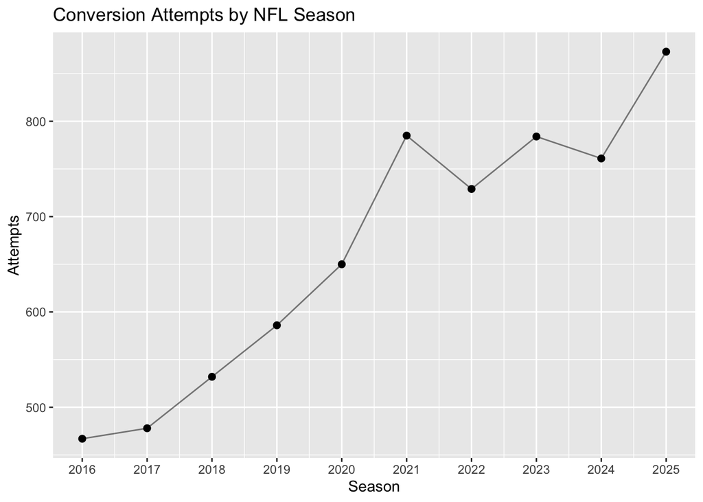

```r
# line plot of conversion attempts over time
ggplot(pbp, aes(x = season, y = fourth_down_attempted)) +
  stat_summary(fun = sum , geom = "line", alpha = 0.5) +
  stat_summary(fun = sum , geom = "point", size = 2) +
  scale_x_continuous(breaks = last10) +
  labs(title = "Conversion Attempts by NFL Season",
       x = "Season", y = "Attempts")
```

From 2016 to 2021, there was an explosion in fourth-down attempts to the point that it looks almost exponential in growth. After that, the attempts seem to level off before increasing again in 2025. Of course, Dan Campbell debuted in 2021, but something else important happened: the NFL regular season expanded from 16 to 17 games. It is possible that the additional game creates more opportunities for fourth-down conversion attempts.

Let’s instead look at the number of conversion attempts by the number of fourth down plays.

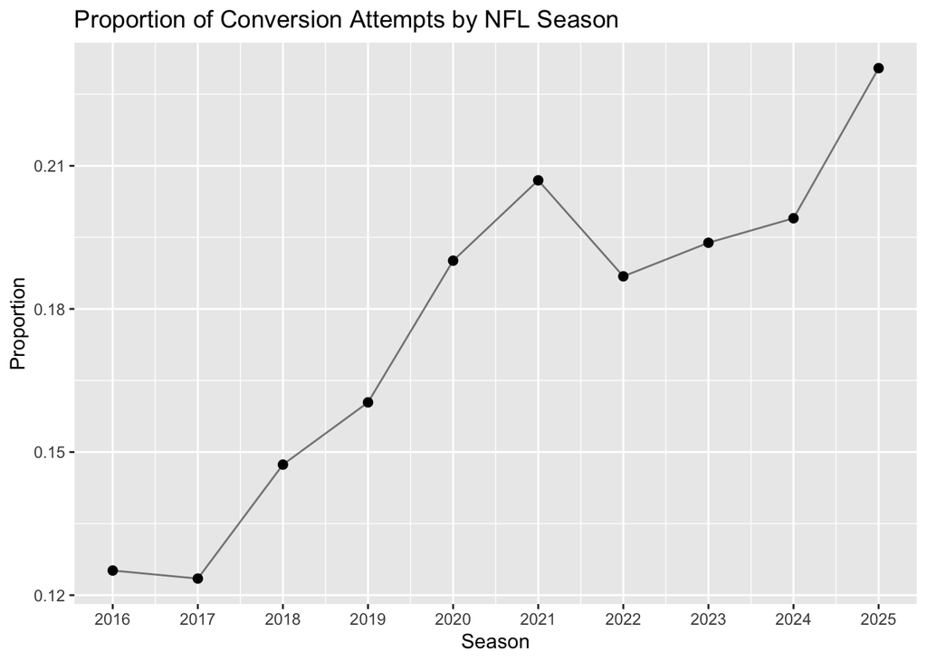

```r
# grouped season tibble
season_stats |>
  group_by(season) |>
  summarize(attempt_pct = sum(fourth_down_attempts) / sum(total_plays)) |>
# line plot of conversion proportion over time
ggplot(aes(x = season, y = attempt_pct)) +
  geom_line(alpha = 0.5) +
  geom_point(size = 2) +
  scale_x_continuous(breaks = last10) +
  labs(title = "Proportion of Conversion Attempts by NFL Season",
       x = "Season", y = "Proportion")
```

This looks almost identical to the count-based plot, so it is safe to say that the extra game is not noticeably skewing the last 5 years of data. Now let’s split out the Detroit Lions from the rest of the league and see if there is distinct visual difference.

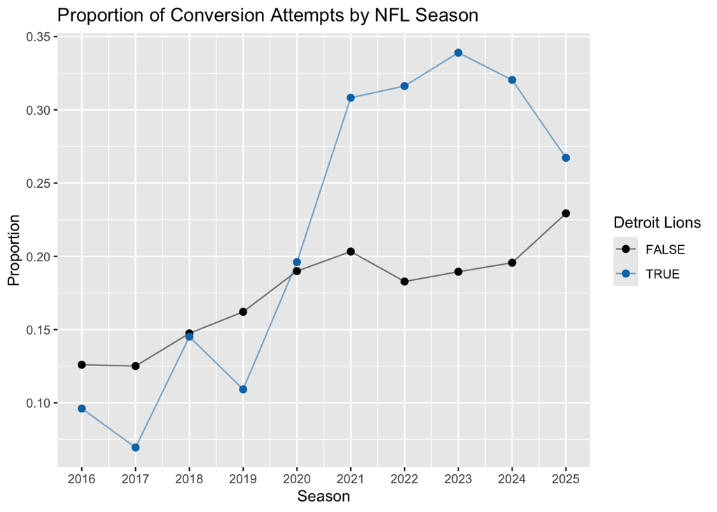

```r
# official honolulu blue color code
honolulu_blue <- "#0076B6"

# grouped season and team tibble
season_stats |>
  group_by(season, detroit) |>
  summarize(attempt_pct = sum(fourth_down_attempts) / sum(total_plays)
            , .groups = "drop") |>
# line plot of conversion proportion over time
ggplot(aes(x = season, y = attempt_pct, color=detroit)) +
  geom_line(alpha = 0.5) +
  geom_point(size = 2) +
  scale_x_continuous(breaks = last10) +
  scale_color_manual(values = c(
  "FALSE" = "black",
  "TRUE" = honolulu_blue)) +
  labs(title = "Proportion of Conversion Attempts by NFL Season",
       x = "Season", y = "Proportion", color = "Detroit Lions")
```

Wow, the Lions experienced a significant jump starting in 2021 when Dan Campbell took over the helm. From 2021 through 2024, the proportion of fourth-down conversion attempts stayed fairly consistent, before dropping in 2025. This is the opposite trend that is observed with the rest of the league.

[figure not shown]

```r
# grouped season and team tibble
season_stats |>
  group_by(posteam) |>
  summarize(attempt_pct = sum(fourth_down_attempts) / sum(total_plays)
            , .groups = "drop") |>
# line plot of conversion proportion over time
ggplot(aes(x = attempt_pct, y = reorder(posteam, attempt_pct), fill=posteam)) +
  geom_col() +
  scale_fill_nfl(alpha = 0.8) +
  theme(axis.text.y.left = element_nfl_logo(size = 1)) +
    labs(title = "Proportion of Conversion Attempts by Team",
         subtitle = "Regular Seasons 2016 - 2025", x = "Proportion", y = "")
```

Since 2016, the Lions have the second-highest proportion of fourth downs that are attempted as a conversion. If we exclude the pre-Campbell era, how does that change things?

[figure not shown]

```r
# grouped season and team tibble
season_stats |>
  filter(season > 2020) |>
  group_by(posteam) |>
  summarize(attempt_pct = sum(fourth_down_attempts) / sum(total_plays)
            , .groups = "drop") |>
# line plot of conversion proportion over time
ggplot(aes(x = attempt_pct, y = reorder(posteam, attempt_pct), fill=posteam)) +
  geom_col() +
  scale_fill_nfl(alpha = 0.8) +
  theme(axis.text.y.left = element_nfl_logo(size = 1)) +
    labs(title = "Proportion of Conversion Attempts by Team",
         subtitle = "Regular Seasons 2021 - 2025", x = "Proportion", y = "")
```

The Lions have by far the highest proportion of fourth down conversion attempts once Campbell took over head coaching duties.